# Statistical Inference Course Project 2

Daniel Resende

February 20, 2015

### Overview

To this project I was supose to perform some test about tooth growth in guinea pigs according to supplementation of Orange Juice and Vitamin C. To chec the results I applied T Test and P Value. To make it more visual, I overlayed distributions and its mean.

```r
library(reshape2)
library(plyr)
library(ggplot2)
library(gridExtra)
```

### Load Data

```r
data(ToothGrowth)
# ToothGrowth$dose <- as.factor(ToothGrowth$dose)
ToothGrowth$supp <- factor(ToothGrowth$supp, levels=c("OJ", "VC"), labels=c("Orange Juice", "Vitamin C"))
```

### Basic Summary

```r
l <- lapply(split(ToothGrowth, ToothGrowth$supp), function(x) {
    lapply(split(x, x$dose), function(x) {
        x$len
    })
})
l <- unlist(l, recursive = FALSE)
lapply(l, summary)
```

```
## $`Orange Juice.0.5`
##    Min. 1st Qu.  Median    Mean 3rd Qu.    Max.
##    8.20    9.70   12.25   13.23   16.18   21.50
##
## $`Orange Juice.1`
##    Min. 1st Qu.  Median    Mean 3rd Qu.    Max.
##   14.50   20.30   23.45   22.70   25.65   27.30
##
## $`Orange Juice.2`
##    Min. 1st Qu.  Median    Mean 3rd Qu.    Max.
##   22.40   24.58   25.95   26.06   27.08   30.90
##
## $`Vitamin C.0.5`
##    Min. 1st Qu.  Median    Mean 3rd Qu.    Max.
##    4.20    5.95    7.15    7.98   10.90   11.50
##
## $`Vitamin C.1`
##    Min. 1st Qu.  Median    Mean 3rd Qu.    Max.
##   13.60   15.27   16.50   16.77   17.30   22.50
##
## $`Vitamin C.2`
##    Min. 1st Qu.  Median    Mean 3rd Qu.    Max.
##   18.50   23.38   25.95   26.14   28.80   33.90
```

### Exploratory Analysis

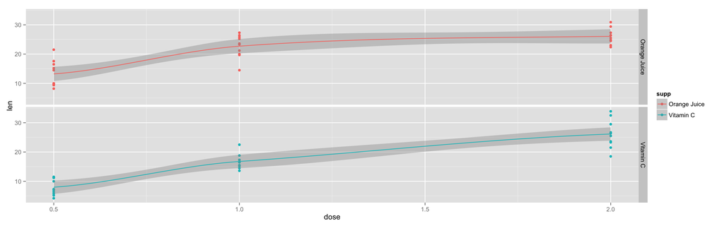

```r
g <- ggplot(ToothGrowth, aes(dose, len, colour=supp)) +
    geom_point() +
    facet_grid(supp ~ .) +
    geom_smooth(method="loess")
print(g)
```

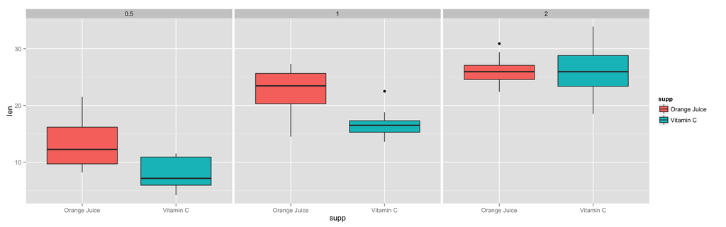

```r
g <- ggplot(ToothGrowth, aes(supp, len)) + geom_boxplot(aes(fill=supp)) + facet_grid(. ~ dose)
print(g)
```

#### Local t.test

I have created a local_t.test function. It basically performs the t.test and plot a density charts of a pair of data. It plot both data distributions and its respective mean.

```r
local_t.test <- function(m, l) {
    # Get the right data
    xind <- m[1]
    yind <- m[2]
    x <- l[[xind]]
    y <- l[[yind]]

    # T Test
    t <- t.test(y, x)

    # Calculate interval
    mdiff <- mean(y) - mean(x)
    conf.int <- mdiff + c(-1, 1) * qt(.975, (length(x)-1 + length(y)-1)) * sqrt(sd(x)^2/length(x) + sd(y)^2/length(y))
    conf.int <- conf.int / sd(x)

    # Formating plot
    local_format <- function(x) {
        format(round(x, 2), nsmall = 2)
    }
    plotTitle <- paste(names(l)[xind], names(l)[yind], sep=" X ")
    plotTitle <- gsub(".0.5", " 0.5", plotTitle)
    plotTitle <- gsub(".1", " 1.0", plotTitle)
    plotTitle <- gsub(".2", " 2.0", plotTitle)
    plotTitle <- paste(plotTitle, "\n",
                       "95% Confidence Interval:",
                       local_format(conf.int[1]),
                       local_format(conf.int[2]))
    plotTitle <- paste(plotTitle, "\n",
                       "P value:", local_format(t$p.value))
    plotTitle <- paste(plotTitle, "\n",
                       "T value:", local_format(t$statistic))

    plotLabel <- c(names(l)[m[1]], names(l)[m[2]])

    # Formatting plot data
    standardizedX <- (x - mean(x)) / sd(x)
    standardizedY <- (y - mean(x)) / sd(x)
    df <- melt(data.frame(standardizedX, standardizedY), id=NULL)
    df$variable <- factor(df$variable, labels=plotLabel)
    meandf <- ddply(df, "variable", summarise, value=mean(value))

    # Plot
    ggplot(df, aes(value, fill=variable)) +
        geom_density(alpha=.5) +
        geom_vline(data=meandf, aes(xintercept=value,  colour=variable),
               linetype="dashed", size=1) +
        xlim(range(c(standardizedX, standardizedY))) +
        theme(legend.position="bottom") +
        ggtitle(plotTitle) +
        xlab("standard deviation")
}
```